# Time series analysis with R

Xu Liu

Time series are a little different from other types of data. Time series data often has long-term trends or periodic patterns that traditional summary statistics don’t capture. To find these patterns, you need to use different types of analyses.

# 1 Autocorrelation Functions

One important property of a time series is the autocorrelation function. You can estimate the autocorrelation function for time series using R’s `acf` function:

```r
acf(x, lag.max = NULL,
    type = c("correlation", "covariance", "partial"),
    plot = TRUE, na.action = na.fail, demean = TRUE, ...)
```

The function `pacf` is an alias for `acf`, except with the default type of **“partial”**:

```r
pacf(x, lag.max, plot, na.action, ...)
```

By default, this function plots the results. As an example, let’s show the autocorrelation function of the turkey price data:

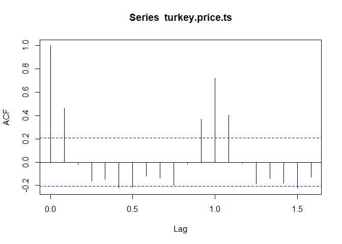

```r
# library(nutshell)
data(turkey.price.ts)
acf(turkey.price.ts)
```

```r
acf(turkey.price.ts,plot=FALSE)
```

```
##
## Autocorrelations of series 'turkey.price.ts', by lag
##
## 0.0000 0.0833 0.1667 0.2500 0.3333 0.4167 0.5000 0.5833 0.6667 0.7500
##  1.000  0.465 -0.019 -0.165 -0.145 -0.219 -0.215 -0.122 -0.136 -0.200
## 0.8333 0.9167 1.0000 1.0833 1.1667 1.2500 1.3333 1.4167 1.5000 1.5833
## -0.016  0.368  0.723  0.403 -0.013 -0.187 -0.141 -0.180 -0.226 -0.130
```

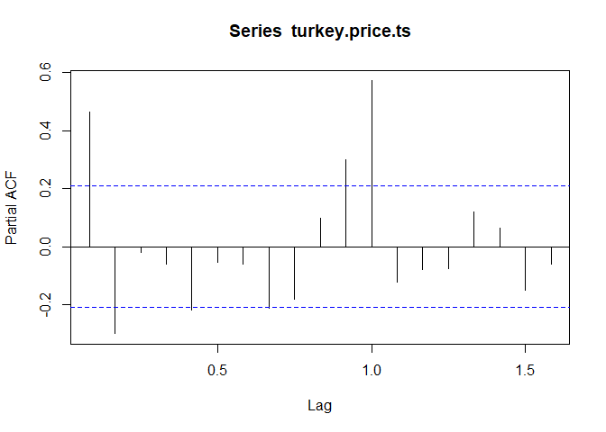

```r
pacf(turkey.price.ts)
```

```r
pacf(turkey.price.ts,plot=FALSE)
```

```
##
## Partial autocorrelations of series 'turkey.price.ts', by lag
##
## 0.0833 0.1667 0.2500 0.3333 0.4167 0.5000 0.5833 0.6667 0.7500 0.8333
##  0.465 -0.300 -0.020 -0.060 -0.218 -0.054 -0.061 -0.211 -0.180  0.098
## 0.9167 1.0000 1.0833 1.1667 1.2500 1.3333 1.4167 1.5000 1.5833
##  0.299  0.571 -0.122 -0.077 -0.075  0.119  0.064 -0.149 -0.061
```

The function `ccf` plots the cross-correlation function for two time series:

```r
ccf(x, y, lag.max = NULL, type = c("correlation", "covariance"),
    plot = TRUE, na.action = na.fail, ...)
```

By default, this function will plot the results. You can suppress the plot (to just view the function) with the argument `plot=FALSE`.

As an example of cross-correlations, we can use average ham prices in the United States. These are included in the `nutshell` package as `ham.price.ts`:

```r
# library(nutshell)
data(ham.price.ts)
ccf(turkey.price.ts, ham.price.ts, plot=FALSE)
```

```
##
## Autocorrelations of series 'X', by lag
##
## -1.0833 -1.0000 -0.9167 -0.8333 -0.7500 -0.6667 -0.5833 -0.5000 -0.4167
##   0.147   0.168  -0.188  -0.259  -0.234  -0.098  -0.004   0.010   0.231
## -0.3333 -0.2500 -0.1667 -0.0833  0.0000  0.0833  0.1667  0.2500  0.3333
##   0.228   0.059  -0.038   0.379   0.124  -0.207  -0.315  -0.160  -0.084
##  0.4167  0.5000  0.5833  0.6667  0.7500  0.8333  0.9167  1.0000  1.0833
##  -0.047  -0.005   0.229   0.223  -0.056  -0.099   0.189   0.039  -0.108
```

# 2 Time Series Models

Time series models are a little different from other models that we’ve seen in R. With most other models, the goal is to predict a value (the response variable) from a set of other variables (the predictor variables). Usually, we explicitly assume that there is no autocorrelation: that the sequence of observations does not matter.

With time series, we assume the opposite: we assume that previous observations help predict future observations.

To fit an autoregressive model to a time series, use the function `ar`:

```r
ar(x, aic = TRUE, order.max = NULL,
   method=c("yule-walker", "burg", "ols", "mle", "yw"),
   na.action, series, ...)
```

Here is a description of the arguments to ar.

| Argument | Description | Default |
| --- | --- | --- |
| x | A time series. |  |
| aic | A logical value that specifies whether the Akaike information criterion is used to choose the order of the model. | `TRUE` |
| order.max | A numeric value specifying the maximum order of the model to fit. | `NULL` |
| method | A character value that specifies the method to use for fitting the model. Specify method=“yw” (or method=“yule-walker”) for the Yule-Walker method, method=“burg” for the Burg method, method=“ols” for … | c(“yule-walker”, “burg”, “ols”, “mle”, “yw”) |
| na.action | A function that specifies how to handle missing values. |  |
| series | A character vector of names for the series. |  |
| demean | A logical value specifying if a mean should be estimated during fitting. |  |
| var.method | Specifies the method used to estimate the innovations variance when method=“ar.burg”. |  |
| `...` | Additional arguments, depending on method. |  |

The `ar` function actually calls one of four other functions, depending on the fit method chosen: `ar.yw`, `ar.burg`, `ar.ols`, or `ar.mle`. As an example, let’s fit an autoregressive model to the turkey price data:

```r
# library(nutshell)
data(turkey.price.ts)
turkey.price.ts.ar <- ar(turkey.price.ts)
turkey.price.ts.ar
```

```
##
## Call:
## ar(x = turkey.price.ts)
##
## Coefficients:
##       1        2        3        4        5        6        7        8
##  0.3353  -0.1868  -0.0024   0.0571  -0.1554  -0.0208   0.0914  -0.0658
##       9       10       11       12
## -0.0952   0.0649   0.0099   0.5714
##
## Order selected 12  sigma^2 estimated as  0.05182
```

You can use the model to predict future values. To do this, use the `predict` function. Here is the method for `ar` objects:

```r
predict(object, newdata, n.ahead = 1, se.fit = TRUE, ...)
```

The argument `object` specifies the model object to use for prediction. You can use `newdata` to specify new data to use for prediction, or `n.ahead` to specify a number of periods ahead to predict. The argument `se.fit` specifies whether to return standard errors of the prediction error.

Here is a forecast for the next 12 months for turkey prices:

```r
predict(turkey.price.ts.ar,n.ahead=12)
```

```
## $pred
##            Jan       Feb       Mar       Apr       May       Jun       Jul
## 2008                                         1.8827277 1.7209182 1.7715016
## 2009 1.5439290 1.6971933 1.5849406 1.7800358
##            Aug       Sep       Oct       Nov       Dec
## 2008 1.9416776 1.7791961 1.4822070 0.9894343 1.1588863
## 2009
##
## $se
##            Jan       Feb       Mar       Apr       May       Jun       Jul
## 2008                                         0.2276439 0.2400967 0.2406938
## 2009 0.2450732 0.2470678 0.2470864 0.2480176
##            Aug       Sep       Oct       Nov       Dec
## 2008 0.2415644 0.2417360 0.2429339 0.2444610 0.2449850
## 2009
```

To take a look at a forecast from an autoregressive model, you can use the function `ts.plot`. This function plots multiple time series on a single chart, even if the times are not overlapping. You can specify colors, line types, or other characteristics of each series as vectors; the ith place in the vector determines the property for the $i^{th}$ series.

Here is how to plot the turkey price time series as a solid line, and a projection 24 months into the future as a dashed line:

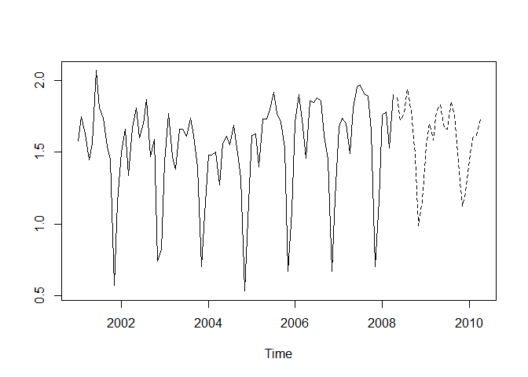

```r
ts.plot(turkey.price.ts, predict(turkey.price.ts.ar,n.ahead=24)$pred, lty=c(1:2))
```

You can also fit autoregressive integrated moving average (**ARIMA**) models in R using the `arima` function:

```r
arima(x, order = c(0, 0, 0),
      seasonal = list(order = c(0, 0, 0), period = NA),
      xreg = NULL, include.mean = TRUE,
      transform.pars = TRUE,
      fixed = NULL, init = NULL,
      method = c("CSS-ML", "ML", "CSS"),
      n.cond, optim.method = "BFGS",
      optim.control = list(), kappa = 1e6)
```

Here is a description of the arguments to arima.

| Argument | Description | Default |
| --- | --- | --- |
| x | A time series. |  |
| order | A numeric vector (p, d, q), where p is the AR order, d is the degree of differencing, and q is the MA order. | c(0, 0, 0) |
| seasonal | A list specifying the seasonal part of the model. The list contains two parts: the order and the period. | list(order = c(0, 0, 0), period = NA) |
| xreg | An (optional) vector or matrix of external regressors (with the same number of rows as x). | `NULL` |
| include.mean | A logical value specifying whether the model should include a mean/intercept term. | `TRUE` |
| tranform.pars | A logical value specifying whether the AR parameters should be transformed to ensure that they remain in the region of stationarity. | `TRUE` |
| fixed | An optional numeric vector specifying fixed values for parameters. (Only `NA` values are varied.) | `NULL` |
| init | A numeric vector of initial parameter values. | `NULL` |
| method | A character value specifying the fitting method to use. The default setting, method=“CSS-ML”, uses conditional sum of squares to find starting values, then maximum likelihood. Specify method=“ML” for … | c(“CSS-ML”, “ML”, “CSS”) |
| n.cond | A numeric value indicating the number of initial values to ignore (only used for conditional sum of squares). |  |

## 2.1 Representing Time Series Data

When you want an R data structure that can represent time series data, you can use the **zoo** and **xts** packages. They define a data structure for time series, and they contain many useful functions for working with time series data. These representations assume you have two vectors: a vector of observations (data) and a vector of dates or times of those observations. The `zoo` function combines them into a zoo object:

```r
# library(zoo)
ts <- zoo(x, dt)
```

The `xts` function is similar, returning an xts object:

```r
# library(xts)
ts <- xts(x, dt)
```

The data, `x`, should be numeric. The vector of dates or datetimes, dt, is called the **index**. Legal indices vary between the packages:

- zoo

  The index can be any ordered values, such as Date objects, POSIXct objects, integers, or even floating-point values.
- xts

  The index must be a supported date or time class. This includes `Date`, `POSIXct`, and `chron objects`. Those should be sufficient for most applications, but you can also use `yearmon`, `yearqtr`, and `dateTime objects`. The `xts` package is more restrictive than zoo because it implements powerful operations that require a time-based index.

Convert between representations of the time series data by using `as.zoo` and `as.xts`:

```r
as.zoo(ts) # Converts ts to a zoo object
as.xts(ts) # Converts ts to an xts object
```

The following example creates a `zoo` object that contains the price of IBM stock for thefirst five days of 2010; it uses `Date` objects for the index:

```r
prices <- c(132.45, 130.85, 130.00, 129.55, 130.85)
dates <- as.Date(c("2010-01-04", "2010-01-05", "2010-01-06", "2010-01-07","2010-01-08"))
ibm.daily <- zoo(prices, dates)
print(ibm.daily)
```

```
## 2010-01-04 2010-01-05 2010-01-06 2010-01-07 2010-01-08
##     132.45     130.85     130.00     129.55     130.85
```

In contrast, the next example captures the price of IBM stock at one-second intervals. It represents time by the number of hours past midnight starting at 9:30 a.m. (1 second $\approx$ 0.00027778 hours):

```r
prices <- c(131.18, 131.20, 131.17, 131.15, 131.17)
seconds <- c(9.5, 9.500278, 9.500556, 9.500833, 9.501111)
ibm.sec <- zoo(prices, seconds)
print(ibm.sec)
```

```
##    9.5 9.5003 9.5006 9.5008 9.5011
## 131.18 131.20 131.17 131.15 131.17
```

Those two examples used a single time series, where the data came from a vector. Both `zoo` and `xts` can also handle **multiple**, **parallel time series**. For this, capture the several time series in a data frame and then create a multivariate time series by calling the `zoo` (or `xts`) function:

```r
ts <- zoo(dfrm, dt) # OR: ts <- xts(dfrm, dt)
```

For example:

```r
m = matrix(1:20,5,4)
dates <- as.Date(c("2010-01-04", "2010-01-05", "2010-01-06", "2010-01-07","2010-01-08"))
zoo(m, dates)
```

```
##
## 2010-01-04 1  6 11 16
## 2010-01-05 2  7 12 17
## 2010-01-06 3  8 13 18
## 2010-01-07 4  9 14 19
## 2010-01-08 5 10 15 20
```

```r
dfrm = data.frame(a = c(1:5),b = c(6:10))
zoo(dfrm, dates)
```

```
##            a  b
## 2010-01-04 1  6
## 2010-01-05 2  7
## 2010-01-06 3  8
## 2010-01-07 4  9
## 2010-01-08 5 10
```

The second argument is a vector of dates (or datetimes) for each observation. There is only one vector of dates for all the time series; in other words, all observations in each row of the data frame must have the same date.

Once the data is captured inside a `zoo` or `xts` object, you can extract the pure data via `coredata`, which returns a simple vector (or matrix):

```r
coredata(ibm.daily)
```

```
## [1] 132.45 130.85 130.00 129.55 130.85
```

You can extract the date or time portion via index:

```r
index(ibm.daily)
```

```
## [1] "2010-01-04" "2010-01-05" "2010-01-06" "2010-01-07" "2010-01-08"
```

The `xts` package is strongly similar to `zoo`. It is optimized for speed and so is especially well suited for processing large volumes of data. It is also clever about converting to and from other time series representations.

One big advantage of capturing data inside a `zoo` or `xts` object is that special-purpose functions become available for printing, plotting, differencing, merging, periodic sampling, applying rolling functions, and other useful operations. There is even a function, `read.zoo`, dedicated to reading time series data from ASCII files.

Remember that the `xts` package can do everything that the `zoo` package can do, so everywhere that this chapter talks about `zoo` objects you can also use `xts` objects.

## 2.2 Plotting Time Series Data

You can use `plot(x)`, which works for `zoo` objects and `xts` objects containing either single or multiple time series.

For a simple vector v of time series observations, you can use either `plot(v,type="l")` or `plot.ts(v)`.

Suppose we have a `zoo` object `dcp`:

```r
# library(datasets)
data(EuStockMarkets)
idx = seq(from = as.Date("1991-05-10"), by = "day", length.out = 1860)
dcp = zoo(coredata(EuStockMarkets), idx)
head(dcp)
```

```
##                DAX    SMI    CAC   FTSE
## 1991-05-10 1628.75 1678.1 1772.8 2443.6
## 1991-05-11 1613.63 1688.5 1750.5 2460.2
## 1991-05-12 1606.51 1678.6 1718.0 2448.2
## 1991-05-13 1621.04 1684.1 1708.1 2470.4
## 1991-05-14 1618.16 1686.6 1723.1 2484.7
## 1991-05-15 1610.61 1671.6 1714.3 2466.8
```

```r
plot(dcp, screens=1)
```

[output not shown]

```r
plot(dcp, screens=c(1,2,3,4))
```

[output not shown]

The `plot` function provides a default label for the x-axis and y-axis, but they are not very informative. It does not provide a default title. So you may need to supply your own `xlab`, `ylab`, and `main`(title) parameters.

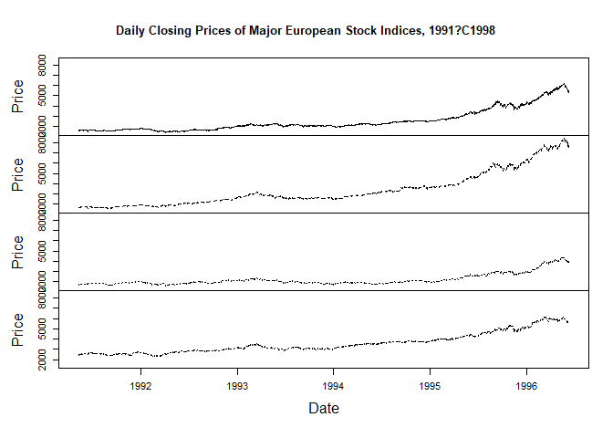

```r
xlab="Date"
ylab="Price"
main="Daily Closing Prices of Major European Stock Indices, 1991?C1998"
lty=c("solid", "dashed", "dotted", "dotdash")
ylim=range(coredata(dcp))
# Plot the two time series in two plots
plot(dcp, screens=c(1,2,3,4), lty=lty, main=main, xlab=xlab, ylab=ylab, ylim=ylim)
```

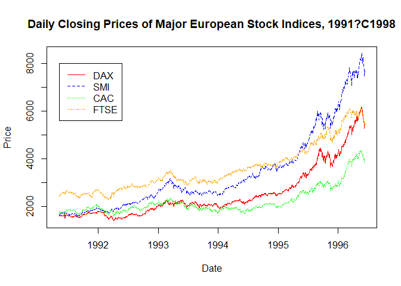

```r
# Plot the two time series in one plot
plot(dcp, screens=1, lty=lty, main=main, xlab=xlab, ylab=ylab, col = c("red", "blue", "green", "orange"))
# Add a legend
legend(as.Date("1991-05-10"), 8000, c("DAX", "SMI", "CAC", "FTSE"), lty=lty, col = c("red", "blue", "green", "orange"))
```

## 2.3 Extracting the Oldest or Newest Observations

You can use `head` to view the oldest observations:

```r
head(ts)
```

And use `tail` to view the newest observations:

```r
tail(ts)
```

The `head` and `tail` functions are generic, so they will work whether your data is stored in a simple vector, a `zoo` object, or an `xts` object. For example:

```r
head(dcp)
```

```
##                DAX    SMI    CAC   FTSE
## 1991-05-10 1628.75 1678.1 1772.8 2443.6
## 1991-05-11 1613.63 1688.5 1750.5 2460.2
## 1991-05-12 1606.51 1678.6 1718.0 2448.2
## 1991-05-13 1621.04 1684.1 1708.1 2470.4
## 1991-05-14 1618.16 1686.6 1723.1 2484.7
## 1991-05-15 1610.61 1671.6 1714.3 2466.8
```

```r
tail(dcp)
```

```
##                DAX    SMI    CAC   FTSE
## 1996-06-06 5598.32 7952.9 4041.9 5680.4
## 1996-06-07 5460.43 7721.3 3939.5 5587.6
## 1996-06-08 5285.78 7447.9 3846.0 5432.8
## 1996-06-09 5386.94 7607.5 3945.7 5462.2
## 1996-06-10 5355.03 7552.6 3951.7 5399.5
## 1996-06-11 5473.72 7676.3 3995.0 5455.0
```

By default, `head` and `tail` show (respectively) the six oldest and six newest observations. You can see more observations by providing a second argument, for example:

```r
tail(dcp, 20)
```

```
##                DAX    SMI    CAC   FTSE
## 1996-05-23 6186.09 8400.8 4368.9 6179.0
## 1996-05-24 6184.10 8412.0 4322.1 6132.7
## 1996-05-25 6081.11 8340.7 4220.1 5989.6
## 1996-05-26 6043.82 8229.2 4235.9 5976.2
## 1996-05-27 6040.58 8205.7 4205.4 5892.3
## 1996-05-28 5854.35 7998.7 4139.5 5836.1
## 1996-05-29 5867.52 8093.0 4122.4 5835.8
## 1996-05-30 5828.74 8102.7 4139.2 5844.1
## 1996-05-31 5906.33 8205.5 4197.6 5910.7
## 1996-06-01 5861.19 8239.5 4177.3 5837.0
## 1996-06-02 5774.38 8139.2 4095.0 5809.7
## 1996-06-03 5718.70 8170.2 4047.9 5736.1
## 1996-06-04 5614.77 7943.2 3976.4 5632.5
## 1996-06-05 5528.12 7846.2 3968.6 5594.1
## 1996-06-06 5598.32 7952.9 4041.9 5680.4
## 1996-06-07 5460.43 7721.3 3939.5 5587.6
## 1996-06-08 5285.78 7447.9 3846.0 5432.8
## 1996-06-09 5386.94 7607.5 3945.7 5462.2
## 1996-06-10 5355.03 7552.6 3951.7 5399.5
## 1996-06-11 5473.72 7676.3 3995.0 5455.0
```

The `xts` package also includes first and last functions, which use calendar periods instead of number of observations. We can use `first` and `last` to select data by number of days, weeks, months, or even years:

```r
first(as.xts(dcp), "3 weeks")
```

```
##                DAX    SMI    CAC   FTSE
## 1991-05-10 1628.75 1678.1 1772.8 2443.6
## 1991-05-11 1613.63 1688.5 1750.5 2460.2
## 1991-05-12 1606.51 1678.6 1718.0 2448.2
## 1991-05-13 1621.04 1684.1 1708.1 2470.4
## 1991-05-14 1618.16 1686.6 1723.1 2484.7
## 1991-05-15 1610.61 1671.6 1714.3 2466.8
## 1991-05-16 1630.75 1682.9 1734.5 2487.9
## 1991-05-17 1640.17 1703.6 1757.4 2508.4
## 1991-05-18 1635.47 1697.5 1754.0 2510.5
## 1991-05-19 1645.89 1716.3 1754.3 2497.4
## 1991-05-20 1647.84 1723.8 1759.8 2532.5
## 1991-05-21 1638.35 1730.5 1755.5 2556.8
## 1991-05-22 1629.93 1727.4 1758.1 2561.0
## 1991-05-23 1621.49 1733.3 1757.5 2547.3
## 1991-05-24 1624.74 1734.0 1763.5 2541.5
## 1991-05-25 1627.63 1728.3 1762.8 2558.5
## 1991-05-26 1631.99 1737.1 1768.9 2587.9
```

```r
last(as.xts(dcp), "10 days")
```

```
##                DAX    SMI    CAC   FTSE
## 1996-06-02 5774.38 8139.2 4095.0 5809.7
## 1996-06-03 5718.70 8170.2 4047.9 5736.1
## 1996-06-04 5614.77 7943.2 3976.4 5632.5
## 1996-06-05 5528.12 7846.2 3968.6 5594.1
## 1996-06-06 5598.32 7952.9 4041.9 5680.4
## 1996-06-07 5460.43 7721.3 3939.5 5587.6
## 1996-06-08 5285.78 7447.9 3846.0 5432.8
## 1996-06-09 5386.94 7607.5 3945.7 5462.2
## 1996-06-10 5355.03 7552.6 3951.7 5399.5
## 1996-06-11 5473.72 7676.3 3995.0 5455.0
```

## 2.4 Subsetting a Time Series

If you want to select one or more elements from a time series, you can index a zoo or xts object by position. Use one or two subscripts, depending upon whether the object contains one time series or multiple time series:

- `ts[i]`

  Selects the ith observation from a single time series
- `ts[j,i]`

  Selects the ith observation of the jth time series of multiple time series

You can index the time series by a date object. Use the same type of object as the index of your time series. This example assumes that the index contains `Date` objects:

```r
ts[as.Date("yyyy-mm-dd")]
```

You can index it by a sequence of dates:

```r
dates <- seq(startdate, enddate, increment)
ts[dates]
```

The `window` function can select a range by start and end date:

```r
window(ts, start=startdate, end=enddate)
```

Recall our small sample of IBM stock prices:

```r
ibm.daily
```

```
## 2010-01-04 2010-01-05 2010-01-06 2010-01-07 2010-01-08
##     132.45     130.85     130.00     129.55     130.85
```

We can select an observation by position, just like selecting elements from a vector:

```r
ibm.daily[2]
```

```
## 2010-01-05
##     130.85
```

```r
ibm.daily[2:4]
```

```
## 2010-01-05 2010-01-06 2010-01-07
##     130.85     130.00     129.55
```

Sometimes it’s more useful to select by date. In this case, our index is built from `Date` objects, so we subscript the time series using a `Date` object (if the index were built from `POSIXct` objects, we’d use a `POSIXct` object):

```r
ibm.daily[as.Date('2010-01-05')]
```

```
## 2010-01-05
##     130.85
```

We can select by a vector of Date objects:

```r
dates <- seq(as.Date('2010-01-04'), as.Date('2010-01-08'), by=2)
ibm.daily[dates]
```

```
## 2010-01-04 2010-01-06 2010-01-08
##     132.45     130.00     130.85
```

The `window` function is easier for selecting a range of consecutive dates:

```r
window(ibm.daily, start=as.Date('2010-01-05'), end=as.Date('2010-01-07'))
```

```
## 2010-01-05 2010-01-06 2010-01-07
##     130.85     130.00     129.55
```

## 2.5 Merging Several Time Series

Suppose that you have two or more time series and you want to merge them into a single time series object. In this case, you can use the zoo object to represent the time series; then use the merge function to combine them:

```r
merge(ts1, ts2)
```

Merging two time series is an incredible headache when the two series have differing timestamps.

```r
daily_idx = seq(from = as.Date("2000-01-02"), by = "day", length.out = 30)
weekly_idx = seq(from = as.Date("2000-01-01"), by = "week", length.out = 6)
ts1 = zoo(rnorm(30), daily_idx)
ts1
```

```
## 2000-01-02 2000-01-03 2000-01-04 2000-01-05 2000-01-06 2000-01-07
##  0.9737556 -0.8728359  0.2784130  1.3754153  1.6987765 -2.3975531
## 2000-01-08 2000-01-09 2000-01-10 2000-01-11 2000-01-12 2000-01-13
##  2.6821324 -0.8695387 -1.3853879  0.1380131 -1.5153835  1.1372844
## 2000-01-14 2000-01-15 2000-01-16 2000-01-17 2000-01-18 2000-01-19
##  1.4571492 -0.5150068  0.6403659  0.4043159 -0.5491450  2.0633122
## 2000-01-20 2000-01-21 2000-01-22 2000-01-23 2000-01-24 2000-01-25
## -0.2536504 -1.0916630  1.5104725  0.5727101  0.2553154 -0.2445711
## 2000-01-26 2000-01-27 2000-01-28 2000-01-29 2000-01-30 2000-01-31
##  0.9808319  0.7601182  0.6755955  1.5439757  1.8410443 -0.8875722
```

```r
ts2 = zoo(rnorm(6), weekly_idx)
ts2
```

```
##  2000-01-01  2000-01-08  2000-01-15  2000-01-22  2000-01-29  2000-02-05
##  0.03448087  0.36390343 -1.42906502 -1.40853638 -0.28024273 -0.75505235
```

Obviously, the two time series have different timestamps because one is daily data and the other is weekly data.

Thank goodness for the `merge` function, which handles the messy details of reconciling the different dates:

```r
merge(ts1, ts2)
```

```
##                   ts1         ts2
## 2000-01-01         NA  0.03448087
## 2000-01-02  0.9737556          NA
## 2000-01-03 -0.8728359          NA
## 2000-01-04  0.2784130          NA
## 2000-01-05  1.3754153          NA
## 2000-01-06  1.6987765          NA
## 2000-01-07 -2.3975531          NA
## 2000-01-08  2.6821324  0.36390343
## 2000-01-09 -0.8695387          NA
## 2000-01-10 -1.3853879          NA
## 2000-01-11  0.1380131          NA
## 2000-01-12 -1.5153835          NA
## 2000-01-13  1.1372844          NA
## 2000-01-14  1.4571492          NA
## 2000-01-15 -0.5150068 -1.42906502
## 2000-01-16  0.6403659          NA
## 2000-01-17  0.4043159          NA
## 2000-01-18 -0.5491450          NA
## 2000-01-19  2.0633122          NA
## 2000-01-20 -0.2536504          NA
## 2000-01-21 -1.0916630          NA
## 2000-01-22  1.5104725 -1.40853638
## 2000-01-23  0.5727101          NA
## 2000-01-24  0.2553154          NA
## 2000-01-25 -0.2445711          NA
## 2000-01-26  0.9808319          NA
## 2000-01-27  0.7601182          NA
## 2000-01-28  0.6755955          NA
## 2000-01-29  1.5439757 -0.28024273
## 2000-01-30  1.8410443          NA
## 2000-01-31 -0.8875722          NA
## 2000-02-05         NA -0.75505235
```

By default, `merge` finds the union of all dates: the output contains all dates from both inputs, and missing observations are filled with `NA` values. You can replace those `NA` values with the most recent observation by using the `na.locf` function from the `zoo` package:

```r
na.locf(merge(ts1, ts2))
```

```
##                   ts1         ts2
## 2000-01-01         NA  0.03448087
## 2000-01-02  0.9737556  0.03448087
## 2000-01-03 -0.8728359  0.03448087
## 2000-01-04  0.2784130  0.03448087
## 2000-01-05  1.3754153  0.03448087
## 2000-01-06  1.6987765  0.03448087
## 2000-01-07 -2.3975531  0.03448087
## 2000-01-08  2.6821324  0.36390343
## 2000-01-09 -0.8695387  0.36390343
## 2000-01-10 -1.3853879  0.36390343
## 2000-01-11  0.1380131  0.36390343
## 2000-01-12 -1.5153835  0.36390343
## 2000-01-13  1.1372844  0.36390343
## 2000-01-14  1.4571492  0.36390343
## 2000-01-15 -0.5150068 -1.42906502
## 2000-01-16  0.6403659 -1.42906502
## 2000-01-17  0.4043159 -1.42906502
## 2000-01-18 -0.5491450 -1.42906502
## 2000-01-19  2.0633122 -1.42906502
## 2000-01-20 -0.2536504 -1.42906502
## 2000-01-21 -1.0916630 -1.42906502
## 2000-01-22  1.5104725 -1.40853638
## 2000-01-23  0.5727101 -1.40853638
## 2000-01-24  0.2553154 -1.40853638
## 2000-01-25 -0.2445711 -1.40853638
## 2000-01-26  0.9808319 -1.40853638
## 2000-01-27  0.7601182 -1.40853638
## 2000-01-28  0.6755955 -1.40853638
## 2000-01-29  1.5439757 -0.28024273
## 2000-01-30  1.8410443 -0.28024273
## 2000-01-31 -0.8875722 -0.28024273
## 2000-02-05 -0.8875722 -0.75505235
```

(Here `locf` stands for ‘last observation carried forward’.) Observe that the NAs were replaced except the first observation (2000-01-01). You can get the intersection of all dates by setting `all=FALSE`:

```r
merge(ts1, ts2, all=FALSE)
```

```
##                   ts1        ts2
## 2000-01-08  2.6821324  0.3639034
## 2000-01-15 -0.5150068 -1.4290650
## 2000-01-22  1.5104725 -1.4085364
## 2000-01-29  1.5439757 -0.2802427
```

Now the output is limited to observations that are **common** to both files.

## 2.6 Filling or Padding a Time Series

When your time series data has missing observations, you can use `merge` function to fill or pad the data with the missing dates/times. First, create a **zero-width** (dataless) `zoo` object with the missing dates/times. Then merge your data with the zero-width object, taking the union of all dates:

```r
empty <- zoo(,dates) # 'dates' is vector of the missing dates
merge(ts, empty, all=TRUE)
```

The `zoo` package includes a handy feature in the constructor for `zoo` objects: you can omit the data and build a **zero-width** object. The object contains no data, just dates. We can use these ‘Frankenstein’ objects to perform such operations as filling and padding on other time series objects.

# 3 The statistical details

-The statistical details of times series can be found [here](http://rpubs.com/xliusufe/ts).